This document provides a very brief introduction to the Prophet API. For a detailed guide on using Prophet, please visit the main site at https://facebook.github.io/prophet/.

Prophet uses the normal model fitting API. We provide a `prophet` function that performs fitting and returns a model object. You can then call `predict` and `plot` on this model object.

First we read in the data and create the outcome variable.

```r
library(readr)
df <- read_csv('../tests/testthat/data.csv')
```

We call the `prophet` function to fit the model. The first argument is the historical dataframe. Additional arguments control how Prophet fits the data.

```r
m <- prophet(df)
```

```
#> Disabling daily seasonality. Run prophet with daily.seasonality=TRUE to override this.
```

We need to construct a dataframe for prediction. The `make_future_dataframe` function takes the model object and a number of periods to forecast:

```r
future <- make_future_dataframe(m, periods = 365)
head(future)
```

```
#>           ds
#> 1 2012-05-18
#> 2 2012-05-21
#> 3 2012-05-22
#> 4 2012-05-23
#> 5 2012-05-24
#> 6 2012-05-25
```

As with most modeling procedures in R, we use the generic `predict` function to get our forecast:

```r
forecast <- predict(m, future)
head(forecast)
```

```
#>           ds    trend additive_terms additive_terms_lower
#> 1 2012-05-18 40.46725      -4.539132            -4.539132
#> 2 2012-05-21 39.98010      -5.454565            -5.454565
#> 3 2012-05-22 39.81772      -5.595548            -5.595548
#> 4 2012-05-23 39.65534      -5.710402            -5.710402
#> 5 2012-05-24 39.49295      -5.790313            -5.790313
#> 6 2012-05-25 39.33057      -6.139026            -6.139026
#>   additive_terms_upper    weekly weekly_lower weekly_upper    yearly
#> 1            -4.539132 0.5600457    0.5600457    0.5600457 -5.099177
#> 2            -5.454565 0.2927224    0.2927224    0.2927224 -5.747287
#> 3            -5.595548 0.3831188    0.3831188    0.3831188 -5.978666
#> 4            -5.710402 0.5051989    0.5051989    0.5051989 -6.215601
#> 5            -5.790313 0.6660785    0.6660785    0.6660785 -6.456392
#> 6            -6.139026 0.5600457    0.5600457    0.5600457 -6.699072
#>   yearly_lower yearly_upper multiplicative_terms
```

[output cut: 20 more lines]

You can use the generic `plot` function to plot the forecast, but you must also pass the model in to be plotted:

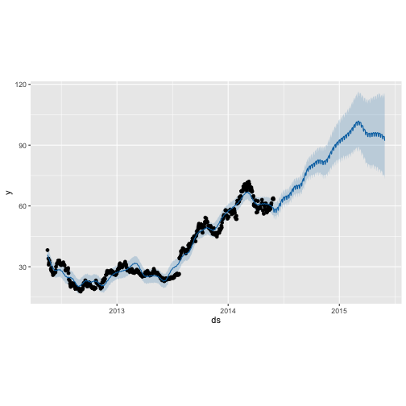

```r
plot(m, forecast)
```

You can plot the components of the forecast using the `prophet_plot_components` function:

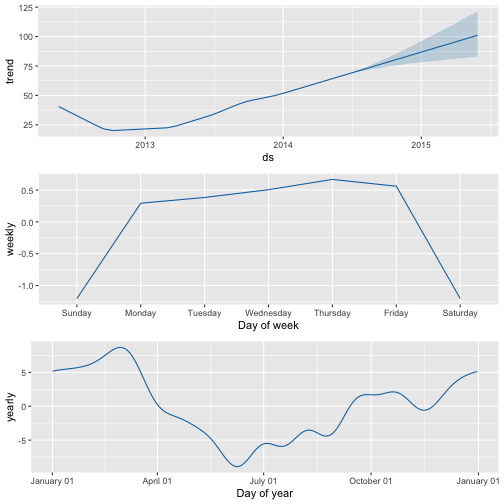

```r
prophet_plot_components(m, forecast)
```